# Practical Machine Learning Course Project

Nick Plummer

11/09/2018

## Executive summary

We aim to predict how well an exercise (in our project specifically is barbell lifts) is done according to a set of variables that have been derived using sensors on the body (belt, forearm, arm, and dumbell) of six participants.

The objective is to correctly predict the variable `classe`, which indicates how well the exercise is performed. `A` indicates that the exercise was performed flawlessly, while `B` to `E` indicate that a mistake was performed.

Steps include:

1. Preparation by loading and sanitising data
2. Application of machine learning algorithms to training dataset to estimate accuracy
3. Application of the best model to the test set to predict the type of performance against twenty instances of barbell lifting.

## Preparation

```r
# Required libraries
library(caret)
library(rpart)
library(rattle)
library(gbm)
library(randomForest)
```

```r
library(ggplot2)
library(gridExtra)
# Get data if not downloaded
if(!file.exists("pml-training.csv")){
  fileUrl <- "https://d396qusza40orc.cloudfront.net/predmachlearn/pml-training.csv"
  download.file(fileUrl,destfile="./pml-training.csv")
}

if(!file.exists("pml-testing.csv")){
  fileUrl <- "https://d396qusza40orc.cloudfront.net/predmachlearn/pml-testing.csv"
  download.file(fileUrl,destfile="./pml-testing.csv")
}

# Load datasets
training <- read.csv("pml-training.csv")
test <- read.csv("pml-testing.csv")

# Remove variables where all values are NA
count_NA <- sapply(test, function(y) sum((is.na(y))))
NA_values <- count_NA[count_NA == 20]
var_remove <- names(NA_values)
training <- training[,!(names(training) %in% var_remove)]
test <- test[,!(names(test) %in% var_remove)]

# Remove non-predictor variables
var_remove2 <- c('user_name','raw_timestamp_part_1', 'raw_timestamp_part_2', 'cvtd_timestamp', 'new_window', 'num_window', 'X')
training <- training[,!(names(training) %in% var_remove2)]
test <- test[,!(names(test) %in% var_remove2)]
```

## Application of ML algorithms

The training dateset is splitted in to two

- `sub_train` to train the models
- `sub_test` for validation

```r
set.seed(69)
partition <- createDataPartition(training$classe, p = 0.8, list = FALSE)
sub_train <- training[partition,]
sub_test <- training[-partition,]
```

A number of models are then applied and assessed:

1. Decision tree (as data is catagorical)
2. Generalised boosted regression
3. Random forest

### Decision tree

```r
# Display model
mod_rpart <- train(classe~., data = sub_train, method = "rpart", trControl = trainControl(method = "cv", number = 5))
mod_rpart
```

```
## CART
##
## 15699 samples
##    52 predictor
##     5 classes: 'A', 'B', 'C', 'D', 'E'
##
## No pre-processing
## Resampling: Cross-Validated (5 fold)
## Summary of sample sizes: 12560, 12559, 12560, 12558, 12559
## Resampling results across tuning parameters:
##
##   cp          Accuracy   Kappa
##   0.03524700  0.5103531  0.36044129
##   0.06105919  0.4176111  0.21071822
##   0.11473075  0.3155008  0.04740574
##
## Accuracy was used to select the optimal model using the largest value.
## The final value used for the model was cp = 0.035247.
```

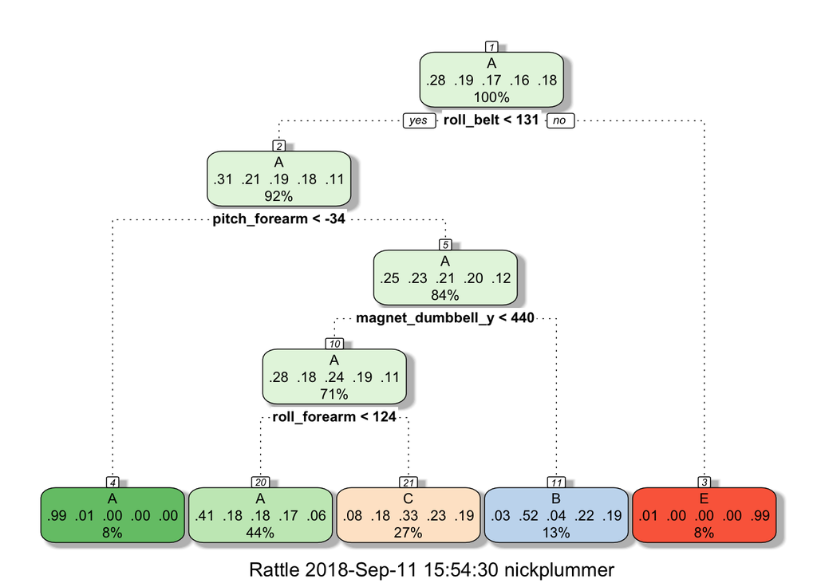

```r
# Graphical decision tree
fancyRpartPlot(mod_rpart$finalModel)
```

```r
# Confusion matrix
pred_rpart <- predict(mod_rpart, sub_test)
confusionMatrix(sub_test$classe, pred_rpart)
```

```
## Confusion Matrix and Statistics
##
##           Reference
## Prediction    A    B    C    D    E
##          A 1009   19   83    0    5
##          B  337  226  196    0    0
##          C  317   22  345    0    0
##          D  281  122  240    0    0
##          E   98  101  189    0  333
##
## Overall Statistics
##
##                Accuracy : 0.4876
##                  95% CI : (0.4719, 0.5034)
##     No Information Rate : 0.5205
##     P-Value [Acc > NIR] : 1
##
##                   Kappa : 0.3304
##  Mcnemar's Test P-Value : NA
##
## Statistics by Class:
##
##                      Class: A Class: B Class: C Class: D Class: E
## Sensitivity            0.4941  0.46122  0.32764       NA  0.98521
## Specificity            0.9431  0.84474  0.88188   0.8361  0.89177
## Pos Pred Value         0.9041  0.29776  0.50439       NA  0.46186
## Neg Pred Value         0.6320  0.91656  0.78141       NA  0.99844
## Prevalence             0.5205  0.12490  0.26842   0.0000  0.08616
## Detection Rate         0.2572  0.05761  0.08794   0.0000  0.08488
## Detection Prevalence   0.2845  0.19347  0.17436   0.1639  0.18379
## Balanced Accuracy      0.7186  0.65298  0.60476       NA  0.93849
```

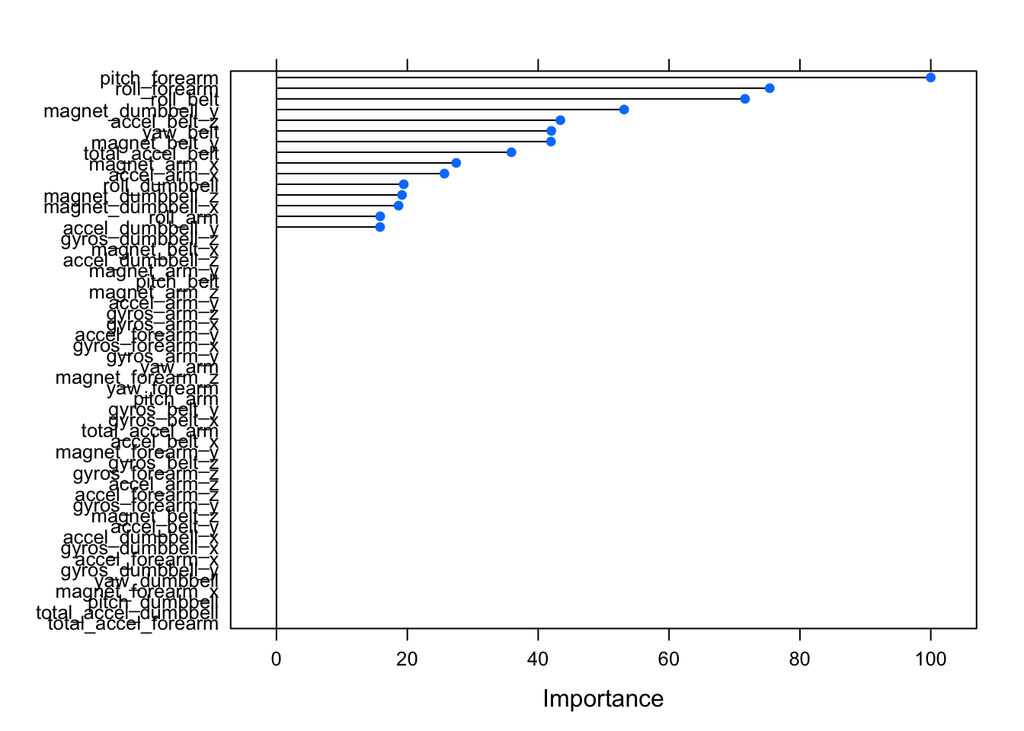

```r
plot(varImp(mod_rpart))
```

The most significant variables were `pitch_forearm`, `roll_forearm`, `roll_belt`, `magnet_dumbbell_y`, and `accel_belt_z`.

### Generalised boosted regression

```r
# Display model
mod_gbm <- train(classe ~ ., data = sub_train, trControl = trainControl(method = "cv", number = 5), method='gbm',  verbose = FALSE)
mod_gbm
```

```
## Stochastic Gradient Boosting
##
## 15699 samples
##    52 predictor
##     5 classes: 'A', 'B', 'C', 'D', 'E'
##
## No pre-processing
## Resampling: Cross-Validated (5 fold)
## Summary of sample sizes: 12560, 12560, 12557, 12559, 12560
## Resampling results across tuning parameters:
##
##   interaction.depth  n.trees  Accuracy   Kappa
##   1                   50      0.7522812  0.6858022
##   1                  100      0.8211361  0.7735699
##   1                  150      0.8522210  0.8129267
##   2                   50      0.8554050  0.8167691
##   2                  100      0.9085939  0.8843165
##   2                  150      0.9311431  0.9128614
##   3                   50      0.8969379  0.8694966
##   3                  100      0.9415894  0.9260764
##   3                  150      0.9610180  0.9506786
##
## Tuning parameter 'shrinkage' was held constant at a value of 0.1
##
## Tuning parameter 'n.minobsinnode' was held constant at a value of 10
## Accuracy was used to select the optimal model using the largest value.
## The final values used for the model were n.trees = 150,
##  interaction.depth = 3, shrinkage = 0.1 and n.minobsinnode = 10.
```

```r
# Confusion matrix
pred_gbm <- predict(mod_gbm, sub_test)
confusionMatrix(pred_gbm, sub_test$classe)
```

```
## Confusion Matrix and Statistics
##
##           Reference
## Prediction    A    B    C    D    E
##          A 1099   18    0    1    1
##          B   14  716   21    1    9
##          C    2   24  652   22    3
##          D    0    0   11  618   11
##          E    1    1    0    1  697
##
## Overall Statistics
##
##                Accuracy : 0.9641
##                  95% CI : (0.9577, 0.9697)
##     No Information Rate : 0.2845
##     P-Value [Acc > NIR] : < 2.2e-16
##
##                   Kappa : 0.9545
##  Mcnemar's Test P-Value : 0.003608
##
## Statistics by Class:
##
##                      Class: A Class: B Class: C Class: D Class: E
## Sensitivity            0.9848   0.9433   0.9532   0.9611   0.9667
## Specificity            0.9929   0.9858   0.9843   0.9933   0.9991
## Pos Pred Value         0.9821   0.9409   0.9275   0.9656   0.9957
## Neg Pred Value         0.9939   0.9864   0.9901   0.9924   0.9926
## Prevalence             0.2845   0.1935   0.1744   0.1639   0.1838
## Detection Rate         0.2801   0.1825   0.1662   0.1575   0.1777
## Detection Prevalence   0.2852   0.1940   0.1792   0.1631   0.1784
## Balanced Accuracy      0.9888   0.9646   0.9687   0.9772   0.9829
```

The GBM was much more accurate than the decision tree model at 96% accuracy.

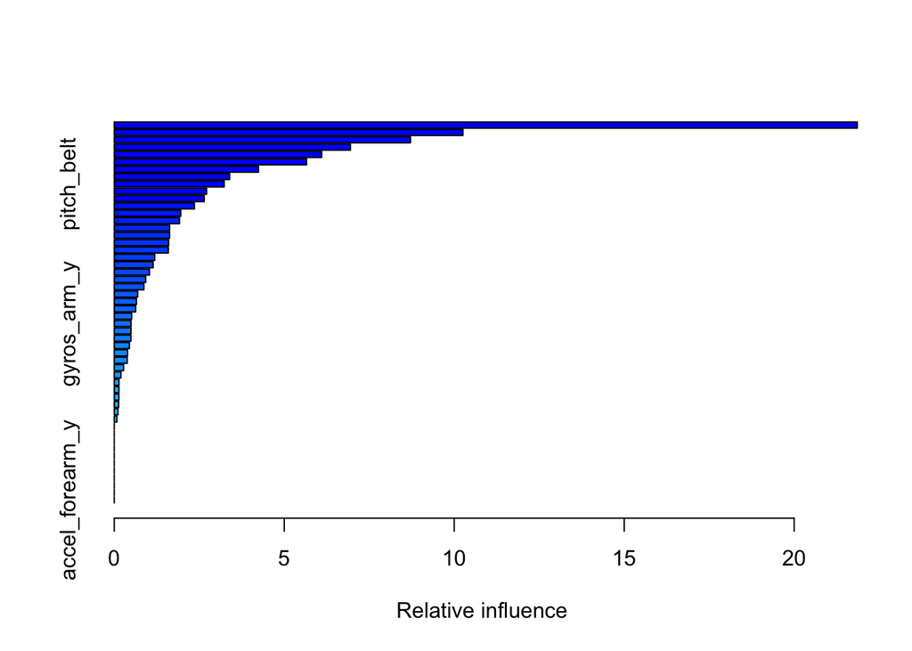

```
##                                       var     rel.inf
## roll_belt                       roll_belt 21.85606214
## pitch_forearm               pitch_forearm 10.25813260
## yaw_belt                         yaw_belt  8.71277261
## magnet_dumbbell_z       magnet_dumbbell_z  6.94672022
## magnet_dumbbell_y       magnet_dumbbell_y  6.10250841
## roll_forearm                 roll_forearm  5.65635630
## magnet_belt_z               magnet_belt_z  4.24362826
## gyros_belt_z                 gyros_belt_z  3.39361723
## pitch_belt                     pitch_belt  3.23377530
## roll_dumbbell               roll_dumbbell  2.71692988
## accel_forearm_x           accel_forearm_x  2.64640773
## accel_dumbbell_y         accel_dumbbell_y  2.35716687
## gyros_dumbbell_y         gyros_dumbbell_y  1.95643619
## magnet_forearm_z         magnet_forearm_z  1.91928265
## accel_dumbbell_z         accel_dumbbell_z  1.62834050
## accel_forearm_z           accel_forearm_z  1.62724473
## yaw_arm                           yaw_arm  1.59962651
## accel_dumbbell_x         accel_dumbbell_x  1.59151067
## magnet_belt_y               magnet_belt_y  1.19134556
## magnet_dumbbell_x       magnet_dumbbell_x  1.14349863
## magnet_arm_z                 magnet_arm_z  1.03618475
## roll_arm                         roll_arm  0.92481189
## magnet_arm_x                 magnet_arm_x  0.87270964
## magnet_belt_x               magnet_belt_x  0.68857415
## magnet_arm_y                 magnet_arm_y  0.65287798
## magnet_forearm_x         magnet_forearm_x  0.63094156
## gyros_dumbbell_x         gyros_dumbbell_x  0.51186230
## gyros_arm_y                   gyros_arm_y  0.49369940
## total_accel_forearm   total_accel_forearm  0.49282625
## total_accel_dumbbell total_accel_dumbbell  0.48884123
## gyros_belt_y                 gyros_belt_y  0.44568508
## accel_belt_z                 accel_belt_z  0.39247429
## accel_arm_x                   accel_arm_x  0.38132893
## accel_arm_y                   accel_arm_y  0.27491028
## magnet_forearm_y         magnet_forearm_y  0.19786241
## gyros_dumbbell_z         gyros_dumbbell_z  0.13910737
## pitch_dumbbell             pitch_dumbbell  0.13902696
## gyros_forearm_z           gyros_forearm_z  0.13711320
## total_accel_arm           total_accel_arm  0.12972768
## accel_arm_z                   accel_arm_z  0.10956887
## yaw_dumbbell                 yaw_dumbbell  0.07850279
## total_accel_belt         total_accel_belt  0.00000000
## gyros_belt_x                 gyros_belt_x  0.00000000
## accel_belt_x                 accel_belt_x  0.00000000
## accel_belt_y                 accel_belt_y  0.00000000
## pitch_arm                       pitch_arm  0.00000000
## gyros_arm_x                   gyros_arm_x  0.00000000
## gyros_arm_z                   gyros_arm_z  0.00000000
## yaw_forearm                   yaw_forearm  0.00000000
## gyros_forearm_x           gyros_forearm_x  0.00000000
## gyros_forearm_y           gyros_forearm_y  0.00000000
## accel_forearm_y           accel_forearm_y  0.00000000
```

```r
summary(mod_gbm)
```

The most significant variables were `roll_belt`, `pitch_forearm`, `yaw_belt`, `magnet_dumbbell_z`,and `magnet_dumbbell_y`. Three of these are in common with the decision tree model.

### Random forest

```r
# Display model
mod_rf <- randomForest(classe ~ ., data = sub_train, trControl = trainControl(method = "cv", number = 5))
mod_rf
```

```
##
## Call:
##  randomForest(formula = classe ~ ., data = sub_train, trControl = trainControl(method = "cv",      number = 5))
##                Type of random forest: classification
##                      Number of trees: 500
## No. of variables tried at each split: 7
##
##         OOB estimate of  error rate: 0.4%
## Confusion matrix:
##      A    B    C    D    E class.error
## A 4461    3    0    0    0 0.000672043
## B    9 3025    4    0    0 0.004279131
## C    0   15 2720    3    0 0.006574142
## D    0    0   19 2551    3 0.008550330
## E    0    0    1    6 2879 0.002425502
```

```r
# Confusion matrix
pred_rf <- predict(mod_rf, sub_test)
confusionMatrix(pred_rf, sub_test$classe)
```

```
## Confusion Matrix and Statistics
##
##           Reference
## Prediction    A    B    C    D    E
##          A 1116    1    0    0    0
##          B    0  758    8    0    0
##          C    0    0  676    7    0
##          D    0    0    0  636    2
##          E    0    0    0    0  719
##
## Overall Statistics
##
##                Accuracy : 0.9954
##                  95% CI : (0.9928, 0.9973)
##     No Information Rate : 0.2845
##     P-Value [Acc > NIR] : < 2.2e-16
##
##                   Kappa : 0.9942
##  Mcnemar's Test P-Value : NA
##
## Statistics by Class:
##
##                      Class: A Class: B Class: C Class: D Class: E
## Sensitivity            1.0000   0.9987   0.9883   0.9891   0.9972
## Specificity            0.9996   0.9975   0.9978   0.9994   1.0000
## Pos Pred Value         0.9991   0.9896   0.9898   0.9969   1.0000
## Neg Pred Value         1.0000   0.9997   0.9975   0.9979   0.9994
## Prevalence             0.2845   0.1935   0.1744   0.1639   0.1838
## Detection Rate         0.2845   0.1932   0.1723   0.1621   0.1833
## Detection Prevalence   0.2847   0.1953   0.1741   0.1626   0.1833
## Balanced Accuracy      0.9998   0.9981   0.9931   0.9943   0.9986
```

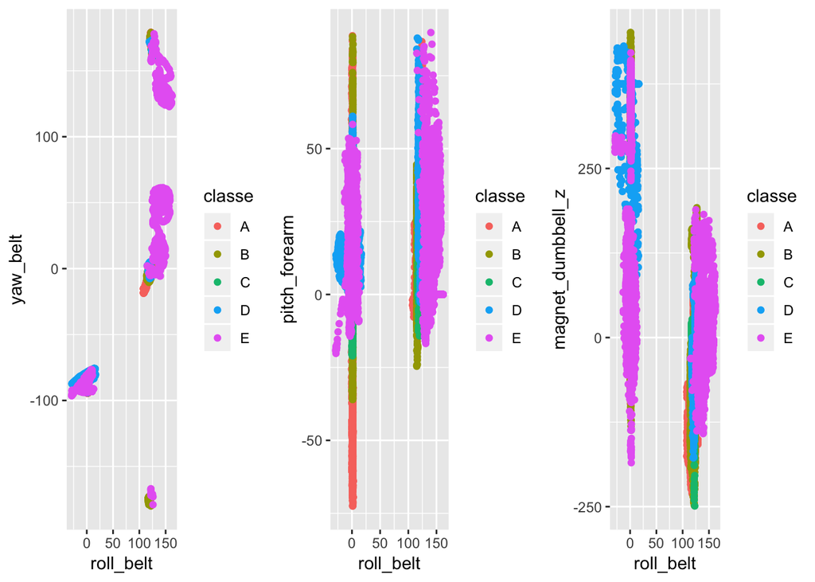

```r
p1 <- qplot(roll_belt, yaw_belt, colour=classe, data=sub_train)
p2 <- qplot(roll_belt, pitch_forearm, colour=classe, data=sub_train)
p3 <- qplot(roll_belt, magnet_dumbbell_z, colour=classe, data=sub_train)
grid.arrange(p1, p2, p3, ncol=3)
```

## Prediction

```r
new_pred <- predict(mod_rf, test, type = "class")
new_pred
```

```
##  1  2  3  4  5  6  7  8  9 10 11 12 13 14 15 16 17 18 19 20
##  B  A  B  A  A  E  D  B  A  A  B  C  B  A  E  E  A  B  B  B
## Levels: A B C D E
```

## Conclusion

Random forest was the superior model for prediction of exercise quality compared to decision trees using `rpart`, and was an incremental improvement over a generalised boosted regression model. This makes intuitive sense as the nominal categories were dependent not only on various variables but also the interaction between them, with more nuance than could be accounted for by a simple decision model. The RF model had over 99% accuracy and fitted well to other subsamples of the data. However, the algorithm may not have as high of accuracy on other samples, particularly ones with different subjects.